# Diet, Labels, and Lifestyle: A NHANES Analysis

Published

2025-03-02

# 1 Setup and Data Ingest

## 1.1 Initial Setup and Loading Package

```r
knitr::opts_chunk$set(warning = FALSE)
```

```r
library(haven)
library(mice)
library(Hmisc)
library(MKinfer)
library(janitor)
library(tinytex)
library(naniar)
library(Epi)
library(epiR)
library(FSA)
library(sessioninfo)
library(car)
library(mosaic)
suppressPackageStartupMessages(library(here))
library(gt)
library(glue)
library(patchwork)
library(broom)
library(rstatix)
library(tidyverse)


theme_set(theme_bw())
knitr::opts_chunk$set(comment = NA, warning = FALSE)
options(dplyr.summarise.inform = FALSE)
```

## 1.2 Loading the Raw Data

```r
# Load and Save P_DEMO (Demographics Data)
demo_raw <- read_xpt(here("data", "raw", "P_DEMO.XPT"))
saveRDS(demo_raw, here("data", "processed", "P_DEMO.Rds"))
demo_raw <- readRDS(here("data", "processed", "P_DEMO.Rds"))

# Load and Save P_DR2TOT (Protein Consumption Data)
protein_raw <- read_xpt(here("data", "raw", "P_DR2TOT.XPT"))
saveRDS(protein_raw, here("data", "processed", "P_DR2TOT.Rds"))
protein_raw <- readRDS(here("data", "processed", "P_DR2TOT.Rds"))

# Load and Save P_CBQPFA (Nutrition Label Use Data)
nut_raw <- read_xpt(here("data", "raw", "P_CBQPFA.XPT"))
saveRDS(nut_raw, here("data", "processed", "P_CBQPFA.Rds"))
nut_raw <- readRDS(here("data", "processed", "P_CBQPFA.Rds"))

# Load and Save P_BMX (BMI Data)
bmi_raw <- read_xpt(here("data", "raw", "P_BMX.XPT"))
saveRDS(bmi_raw, here("data", "processed", "P_BMX.Rds"))
bmi_raw <- readRDS(here("data", "processed", "P_BMX.Rds"))

# Load and Save P_ALQ (Alcohol Consumption Data)
alc_raw <- read_xpt(here("data", "raw", "P_ALQ.XPT"))
saveRDS(alc_raw, here("data", "processed", "P_ALQ.Rds"))
alc_raw <- readRDS(here("data", "processed", "P_ALQ.Rds"))
```

## 1.3 Contents of the Raw Tibbles

Five tibbles were successfully loaded, each containing a subset of variables that will be used in the final analysis. Below, we verify the dimensions of each dataset to ensure they contain the expected number of observations and variables.

```r
dim(demo_raw)
```

```
[1] 15560    29
```

The `demo_raw` contains 15560 rows and 29 variables.

```r
dim(protein_raw)
```

```
[1] 14300    85
```

The dataset `protein_raw` contains 14300 rows and 85 variables.

```r
dim(nut_raw)
```

```
[1] 8552   66
```

The dataset `nut_raw` contains 8552 rows and 66 variables.

```r
dim(bmi_raw)
```

```
[1] 14300    22
```

The dataset `bmi_raw` contains 14300 rows and 22 variables.

```r
dim(alc_raw)
```

```
[1] 8965   10
```

The dataset `alc_raw` contains 8965 rows and 10 variables.

## 1.4 Merging the Data

To ensure all variables are stored within a single tibble, the data sets will be merged by their common column, `SEQN` which is a unique numerical identifier for each subject.

```r
comdata <- left_join(demo_raw, protein_raw, by = "SEQN")
comdata2 <- left_join(comdata, nut_raw, by = "SEQN")
comdata3 <- left_join(comdata2, bmi_raw, by = "SEQN")
comdata4 <- left_join(comdata3, alc_raw, by = "SEQN")

dim(comdata4)
```

```
[1] 15560   208
```

Previously, the data sets contained a total of 212 variables (29 + 85 + 66 + 22 + 10). After merging, the final dataset contains 208 variables. This reduction occurs because `SEQN` is present in all five data sets and is used as the key to merge them. Since each merge retains only one instance of `SEQN`, a total of four duplicate columns are removed, leading to (212 - 4) = 208 columns in the final merged dataset.

## 1.5 Checking the Merge

To verify that each row represents a unique individual, we will check whether the number of unique `SEQN` identifiers matches the total number of rows in the merged dataset.

```r
identical(n_distinct(comdata4$SEQN), comdata4 %>% nrow())
```

```
[1] TRUE
```

If the output returns TRUE, this confirms that each row correctly corresponds to one unique `SEQN` value, ensuring there are no duplicate subject entries.

## 1.6 Selecting the Variables

The merged dataset, `comdata4`, contains over 200 variables, but not all will be used in the final analysis. We will retain only those variables that are essential for analysis, subject identification, and further data cleaning.

```r
NH_data <- comdata4 %>% select(SEQN, RIDAGEYR, RIDSTATR, RIAGENDR, DR2TPROT, DBQ750, BMXBMI, DMDEDUC2, ALQ151)
```

We have selected the variables:

- `SEQN` - Unique identifier for each subject.
- `RIDAGEYR` and `RIDSTATR` - Used to define the population of interest.
- `RIAGENDR`, `DR2TPROT`, `DBQ750`, `BMXBMI`, `DMDEDUC2`, `ALQ151` - Variables for analysis

# 2 Cleaning the Data

## 2.1 The Variables

There are nine variables that will be used.

### 2.1.1 Identification and Population Variables

1. `SEQN` - The unique identification number assigned to each subject.

### 2.1.2 Quantitative Variables

2. `RIDAGEYR` - The subjects age, in years
3. `DR2TPROT` – The subject’s total protein consumption, measured in grams.
4. `BMXBMI` - The subjects body mass index, in kg/m<sup>2</sup>

### 2.1.3 Binary Variables

5. `RIDSTATR` – The subject’s examination and interview status: (Interview Only, Interview and examination Complete)
6. `RIAGENDR` - The subjects gender (Male, female)
7. `ALQ151` – Response to the question: “*Have you ever in a point in your life had 4 or 5 drinks every day?*” (Yes, No)

### 2.1.4 Multi-Categorical Variables

8. `DBQ750` – How often the subject reads nutrition labels before purchasing food (Always, Most of the time, Sometimes, Rarely, Never)
9. `DMDEDUC2` - The subject’s highest level of education completed (“Less Than 9th Grade, 9-11th Grade, High School/GED or Equivalent, Some College or AA degree, College Graduate or above)

## 2.2 Labeling Factors

All categorical variables (`RIAGENDR`, `RIDSTATR`, `DMDEDUC2`, `DBQ750`, `ALQ151`) will be converted from numeric values to factors for better interpret ability. Additionally, any categorical variable with values 7 or 9 (indicating “I don’t know” or refusal to answer) will be treated as missing values.

```r
NH_data <- NH_data %>% mutate(SEQN = as.character(SEQN),
                 RIAGENDR = factor(RIAGENDR, levels = c(1,2), labels = c("Male", "Female")),
                 RIDSTATR = factor(RIDSTATR, levels = c(1, 2), labels = c("Missing Examination", "Completed Examination and Interview")),
                 DMDEDUC2 = factor(DMDEDUC2, levels = c(1,2,3,4,5), labels = c("Less Than 9th Grade", "9-11th Grade", "High School/GED or Equivalent", "Some College or AA degree", "College Graduate or above")),
                 DBQ750 = factor(DBQ750, levels = c(1,2,3,4,5), labels = c("Always", "Most of the time", "Sometimes", "Rarely", "Never")),
                 ALQ151 = factor(ALQ151, levels = c(1,2), labels = c("Yes", "No")))
```

`SEQN` was converted to a character type to maintain it as a unique identifier rather than a numeric value.

## 2.3 Filtering for Population of Interest

The dataset `NH_data` will be filtered to include only subjects who meet the following criteria:

- Age between 21 and 79 years (`RIDAGEYR`)
- Completed both the NHANES examination and interview (`RIDSTATR`)

```r
NH_data <- NH_data %>% filter(RIDAGEYR >= 21 & RIDAGEYR != 80, RIDSTATR == "Completed Examination and Interview")
nrow(NH_data)
```

```
[1] 7853
```

After applying these filters, the `NH_data` tibble now contains 7,853 observations.

## 2.4 Checking the Quantitative Variables

The `NH_data` dataset contains three quantitative variables:

- `RIDAGEYR` – Age of the subject (in years).
- `DR2TPROT` – Total protein consumption (in grams).
- `BMXBMI` – Body mass index (BMI) (in kg/m²).

To ensure these variables have plausible values and to assess the number of missing values, we generate summary statistics:

```r
df_stats(~ RIDAGEYR + DR2TPROT + BMXBMI,  data = NH_data) %>% gt() %>%
  tab_options(table.width = pct(75)) %>%
  cols_align(align = "center") %>% fmt_number(decimals = 2, columns = c(2:8))
```

| response | min | Q1 | median | Q3 | max | mean | sd | n | missing |
| --- | --- | --- | --- | --- | --- | --- | --- | --- | --- |
| RIDAGEYR | 21.00 | 35.00 | 50.00 | 63.00 | 79.00 | 49.32 | 16.01 | 7853 | 0 |
| DR2TPROT | 0.00 | 48.95 | 69.45 | 96.32 | 417.30 | 76.64 | 40.82 | 6178 | 1675 |
| BMXBMI | 14.60 | 25.00 | 28.90 | 34.00 | 92.30 | 30.24 | 7.68 | 7736 | 117 |

## 2.5 Checking Binary Variables

The `NH_data` dataset contains three binary variables:

- `RIDSTATR` – Examination and interview completion status.
- `RIAGENDR` – Gender of the subject.
- `ALQ151` – Response to the question: “Have you ever, at any point in your life, had 4 or 5 drinks every day?”

We will verify that these variables contain correct values and assess the number of missing values.

### 2.5.1 The `RIDSTATR` Variable

The `RIDSTATR` has two levels:

- “Missing Examination”
- “Completed Examination and Interview”.

Since we filtered the dataset to include only subjects who completed both, we will verify that this filtering was applied correctly.

```r
NH_data %>% tabyl(RIDSTATR) %>% gt() %>%
  tab_options(table.width = pct(75)) %>%
  cols_align(align = "center")
```

| RIDSTATR | n | percent |
| --- | --- | --- |
| Missing Examination | 0 | 0 |
| Completed Examination and Interview | 7853 | 1 |

There are no subjects with a *“Missing Examination”* and the number of subjects who completed the examination and interview corresponds to the number of rows in the `NH_data` tibble (7853 observations). This confirms that our filtering was applied correctly.

### 2.5.2 The `RIAGENDR` Variable

The `RIAGENDR` variable represents the gender of each subject and has two levels:

- Male
- Female

We will check for any missing values in this variable.

```r
NH_data %>% tabyl(RIAGENDR) %>% gt() %>%
  tab_options(table.width = pct(75)) %>%
  cols_align(align = "center") %>% fmt_number(decimals = 2, columns = 3)
```

| RIAGENDR | n | percent |
| --- | --- | --- |
| Male | 3794 | 0.48 |
| Female | 4059 | 0.52 |

The dataset contains 3,794 males and 4,059 females. There are no missing values for gender, confirming that every subject has their gender recorded.

### 2.5.3 The `ALQ151` Variable

The ALQ151 variable represents responses to the question: *“Have you ever, at any point in your life, had 4 or 5 drinks every day?”*

It has two levels:

- *“Yes”*
- *“No”*

```r
NH_data %>% tabyl(ALQ151) %>% gt() %>%
  tab_options(table.width = pct(75)) %>%
  cols_align(align = "center") %>% fmt_number(decimals = 2, columns = c(3:4))
```

| ALQ151 | n | percent | valid_percent |
| --- | --- | --- | --- |
| Yes | 1061 | 0.14 | 0.16 |
| No | 5633 | 0.72 | 0.84 |
| NA | 1159 | 0.15 | NA |

1,061 subjects responded *“Yes”*. 5,633 subjects responded *“No”*. A total of 6,694 subjects provided a response. There are 1,159 missing values for this variable.

## 2.6 Checking Multi-Categorical Variables

The `NH_data` dataset contains two multi-categorical variables:

- *DBQ750* – Frequency of reading nutrition labels before purchasing food.
- *DMDEDUC2* – Highest level of education completed.

We will check the number of observations for each level of these variables and assess the number of missing values.

### 2.6.1 The `DBQ750` Variable

The *DBQ750* variable represents how often a subject reads nutrition labels before purchasing food. It has five levels:

- *Always*
- *Most of the time*
- *Sometimes*
- *Rarely*
- *Never*

We will check the distribution of responses and assess the number of missing values.

```r
NH_data %>% tabyl(DBQ750) %>% gt() %>%
  tab_options(table.width = pct(75)) %>%
  cols_align(align = "center") %>% fmt_number(decimals = 2, columns = c(3:4))
```

| DBQ750 | n | percent | valid_percent |
| --- | --- | --- | --- |
| Always | 885 | 0.11 | 0.15 |
| Most of the time | 1451 | 0.18 | 0.25 |
| Sometimes | 2056 | 0.26 | 0.36 |
| Rarely | 766 | 0.10 | 0.13 |
| Never | 625 | 0.08 | 0.11 |
| NA | 2070 | 0.26 | NA |

5,783 subjects provided a response for `DBQ750`. 2,070 subjects have missing values for this variable.

### 2.6.2 The `DMDEDUC2` Variable

The DMDEDUC2 variable represents the highest level of education completed by each subject. It has five levels:

- *Less Than 9th Grade*
- *9-11th Grade*
- *High School/GED or Equivalent*
- *Some College or AA Degree*
- *College Graduate or Above*

We will check the distribution of responses and assess the number of missing values.

```r
NH_data %>% tabyl(DMDEDUC2) %>% gt() %>%
  tab_options(table.width = pct(75)) %>%
  cols_align(align = "center") %>% fmt_number(decimals = 2, columns = c(3:4))
```

| DMDEDUC2 | n | percent | valid_percent |
| --- | --- | --- | --- |
| Less Than 9th Grade | 602 | 0.08 | 0.08 |
| 9-11th Grade | 843 | 0.11 | 0.11 |
| High School/GED or Equivalent | 1868 | 0.24 | 0.24 |
| Some College or AA degree | 2569 | 0.33 | 0.33 |
| College Graduate or above | 1963 | 0.25 | 0.25 |
| NA | 8 | 0.00 | NA |

7,845 subjects provided a response for DMDEDUC2.The level with the fewest responses is “Less Than 9th Grade” with 602 subjects. There are 8 missing values for this variable.

## 2.7 Creating the Analytic Tibble

The `NH_data` tibble will be updated to retain only the variables necessary for the four upcoming analyses, along with the unique subject identifier (`SEQN`).

```r
NH_data <- NH_data %>% select(SEQN, RIAGENDR:ALQ151)
dim(NH_data)
```

```
[1] 7853    7
```

The updated `NH_data` tibble now contains:

- 7 variables (columns)
- 7,853 observations (rows)

This tidy dataset ensures that only the relevant variables are retained for further analysis.

## 2.8 Listing of Missing Values

Before proceeding with the analysis, we will check which variables contain missing values and determine the number of missing observations for each.

```r
miss_var_summary(NH_data) %>% gt() %>%
  tab_options(table.width = pct(75)) %>%
  cols_align(align = "center") %>% fmt_number(decimals = 2, columns = 3)
```

| variable | n_miss | pct_miss |
| --- | --- | --- |
| DBQ750 | 2070 | 26.4 |
| DR2TPROT | 1675 | 21.3 |
| ALQ151 | 1159 | 14.8 |
| BMXBMI | 117 | 1.49 |
| DMDEDUC2 | 8 | 0.102 |
| SEQN | 0 | 0 |
| RIAGENDR | 0 | 0 |

Overall there are five variables with missing values:

- `DBQ750` - 2070 missing values
- `DR2TPROT` - 1675 missing values
- `ALQ151` - 1159 missing values
- `BMXBMI` - 117 missing values
- `DMDEDUC2` - 8 missing values

# 3 Codebook and Data Description

## 3.1 Codebook

The following codebook provides information about the seven variables in the tidy dataset `NH_data`. The “Type” column indicates whether a variable is character, quantitative, or categorical. For categorical variables, the number of levels is specified. The number of missing values is shown in brackets for variables that contain missing data. The “Description and Levels” column explains what each variable represents and, if applicable, lists its levels.

| Variable | Type | Description and Levels |
| --- | --- | --- |
| `SEQN` | Character | Respondent identification number |
| `RIAGENDR` | Categorical- 2 | Male, female: The subjects gender |
| `DR2TPROT` | Quantitative | Total protein consumption over twenty-four hours in grams [**1675 NA**] |
| `DBQ750` | Categorical-5 | Always, Most of the time, Sometimes, Rarely, Never: How often do you read the nutrition label before purchasing a food item? [**2070 NA**] |
| `BMXBMIL` | Quantitative | The subjects body mass index, in kg/m<sup>2</sup> [**117 NA**] |
| `DMDEDUC2` | Categorical-5 | Less Than 9th Grade, 9-11th Grade, High School/GED or Equivalent, Some College or AA degree, College Graduate or above: The subjects highest level of education [**8 NA**] |
| `ALQ151` | Categorical- 2 | Yes, no: Have you ever had a period in your life where you consumed 4 or 5 drinks almost every day? [**1159** **NA**] |

## 3.2 Analytic Tibble

The following check shows that the `NH_data` tibble is in a tibble data structure:

```r
NH_data
```

```
# A tibble: 7,853 × 7
   SEQN   RIAGENDR DR2TPROT DBQ750           BMXBMI DMDEDUC2              ALQ151
   <chr>  <fct>       <dbl> <fct>             <dbl> <fct>                 <fct>
 1 109266 Female       62.9 Most of the time   37.8 College Graduate or … No
 2 109271 Male        140.  Sometimes          29.7 9-11th Grade          Yes
 3 109273 Male         81.0 Sometimes          21.9 Some College or AA d… No
 4 109274 Male         47.9 Always             30.2 Some College or AA d… No
 5 109282 Male         94.7 Sometimes          26.6 College Graduate or … No
 6 109284 Female      141.  Sometimes          39.1 9-11th Grade          <NA>
 7 109286 Female      105.  Rarely             28.9 College Graduate or … <NA>
 8 109290 Female      102.  Most of the time   28.1 College Graduate or … No
 9 109291 Female       21.8 Sometimes          31.3 College Graduate or … <NA>
10 109292 Male         NA   <NA>               30.5 High School/GED or E… No
# ℹ 7,843 more rows
```

Further confirmatory check

```r
is_tibble(NH_data)
```

```
[1] TRUE
```

## 3.3 Data Summary

The following is a summary of the `NH_data` tibble, filtered to include only the specific population of interest and the relevant variables for analysis.

```r
NH_data %>% describe()
```

```
.

 7  Variables      7853  Observations
--------------------------------------------------------------------------------
SEQN
       n  missing distinct
    7853        0     7853

lowest : 109266 109271 109273 109274 109282, highest: 124815 124817 124818 124821 124822
--------------------------------------------------------------------------------
RIAGENDR
       n  missing distinct
    7853        0        2

Value        Male Female
Frequency    3794   4059
Proportion  0.483  0.517
--------------------------------------------------------------------------------
DR2TPROT : Protein (gm)
       n  missing distinct     Info     Mean      Gmd      .05      .10
    6178     1675     5603        1    76.64    43.16    24.71    33.52
     .25      .50      .75      .90      .95
   48.95    69.45    96.32   126.93   150.76

lowest : 0      0.58   1.06   1.13   1.27  , highest: 322.3  329.56 345.53 352.25 417.3
--------------------------------------------------------------------------------
DBQ750
       n  missing distinct
    5783     2070        5

Value                Always Most of the time        Sometimes           Rarely
Frequency               885             1451             2056              766
Proportion            0.153            0.251            0.356            0.132

Value                 Never
Frequency               625
Proportion            0.108
--------------------------------------------------------------------------------
BMXBMI : Body Mass Index (kg/m**2)
       n  missing distinct     Info     Mean      Gmd      .05      .10
    7736      117      447        1    30.24    8.191    20.40    21.90
     .25      .50      .75      .90      .95
   25.00    28.90    34.00    40.10    44.42

lowest : 14.6 14.8 14.9 15   15.1, highest: 80.6 82   84.4 86.2 92.3
--------------------------------------------------------------------------------
DMDEDUC2
       n  missing distinct
    7845        8        5

Less Than 9th Grade (602, 0.077), 9-11th Grade (843, 0.107), High School/GED or
Equivalent (1868, 0.238), Some College or AA degree (2569, 0.327), College
Graduate or above (1963, 0.250)
--------------------------------------------------------------------------------
ALQ151
       n  missing distinct
    6694     1159        2

Value        Yes    No
Frequency   1061  5633
Proportion 0.159 0.841
--------------------------------------------------------------------------------
```

# 4 Imputation

To address missing values in the dataset, we applied multiple imputation using the `mice` package. This approach was chosen to minimize bias and preserve statistical power, as complete-case analysis could lead to a substantial loss of data. Analyzing the patterns of missingness suggested that data were primarily Missing at Random (MAR), meaning the probability of missingness was related to observed variables rather than being completely random. Given this, imputation was performed separately for numerical and categorical variables: Predictive Mean Matching (PMM) was used for continuous variables (`DR2TPROT`, `BMXBMI`), logistic regression was applied to binary variables (`ALQ151`), and multinomial logistic regression was used for multi-category variables (`DBQ750`, `DMDEDUC2`). Five imputed data sets were generated, and a completed dataset was extracted for analysis. Post-imputation checks confirmed that the imputed values aligned with observed distributions, ensuring that the process did not introduce artificial distortions.

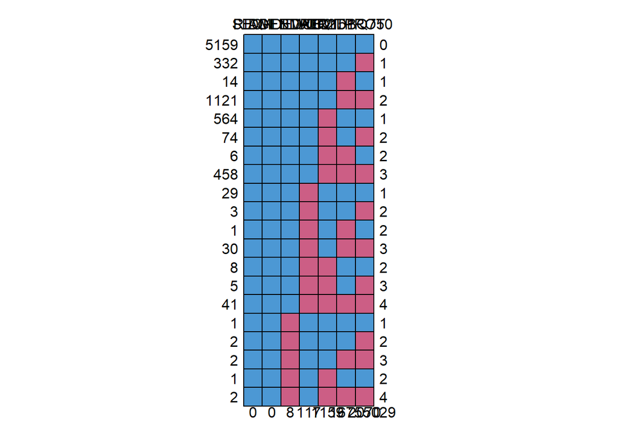

```
     SEQN RIAGENDR DMDEDUC2 BMXBMI ALQ151 DR2TPROT DBQ750
5159    1        1        1      1      1        1      1    0
332     1        1        1      1      1        1      0    1
14      1        1        1      1      1        0      1    1
1121    1        1        1      1      1        0      0    2
564     1        1        1      1      0        1      1    1
74      1        1        1      1      0        1      0    2
6       1        1        1      1      0        0      1    2
458     1        1        1      1      0        0      0    3
29      1        1        1      0      1        1      1    1
3       1        1        1      0      1        1      0    2
1       1        1        1      0      1        0      1    2
30      1        1        1      0      1        0      0    3
8       1        1        1      0      0        1      1    2
5       1        1        1      0      0        1      0    3
41      1        1        1      0      0        0      0    4
1       1        1        0      1      1        1      1    1
2       1        1        0      1      1        1      0    2
2       1        1        0      1      1        0      0    3
1       1        1        0      1      0        1      1    2
2       1        1        0      1      0        0      0    4
        0        0        8    117   1159     1675   2070 5029
```

```r
md.pattern(NH_data)
```

Defining the imputation method for each variable.

```r
impute_methods <- make.method(NH_data)

impute_methods["SEQN"] <- ""
impute_methods["DR2TPROT"] <- "pmm"
impute_methods["BMXBMI"] <- "pmm"
impute_methods["ALQ151"] <- "logreg"
impute_methods["DBQ750"] <- "polyreg"
impute_methods["DMDEDUC2"] <- "polyreg"
```

Multiple imputation will be down using 5 imputed data sets

```r
imp_model <- mice(NH_data, method = impute_methods, m = 5, seed = 444)
```

```r
summary(imp_model)
```

```
Class: mids
Number of multiple imputations:  5
Imputation methods:
     SEQN  RIAGENDR  DR2TPROT    DBQ750    BMXBMI  DMDEDUC2    ALQ151
       ""        ""     "pmm" "polyreg"     "pmm" "polyreg"  "logreg"
PredictorMatrix:
         SEQN RIAGENDR DR2TPROT DBQ750 BMXBMI DMDEDUC2 ALQ151
SEQN        0        1        1      1      1        1      1
RIAGENDR    0        0        1      1      1        1      1
DR2TPROT    0        1        0      1      1        1      1
DBQ750      0        1        1      0      1        1      1
BMXBMI      0        1        1      1      0        1      1
DMDEDUC2    0        1        1      1      1        0      1
Number of logged events:  1
  it im dep     meth  out
1  0  0     constant SEQN
```

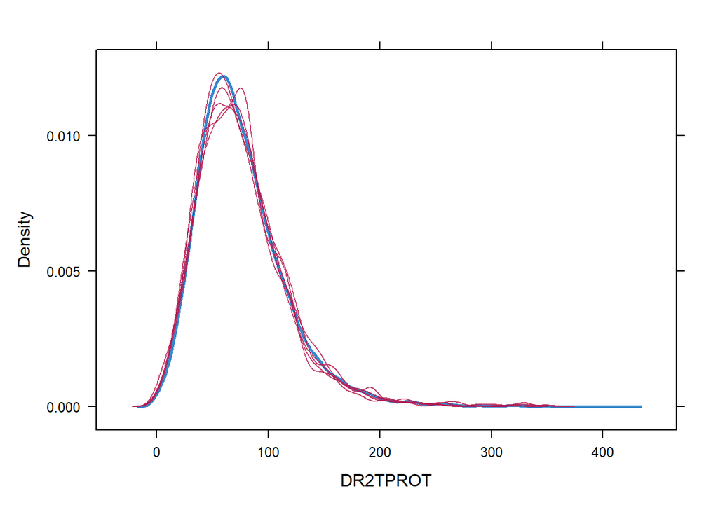

```r
densityplot(imp_model, ~DR2TPROT)
```

To assess the effectiveness of our multiple imputation process, we generated density plots comparing the distribution of observed and imputed values for `DR2TPROT` (total protein consumption). The plot shows that the imputed values (red lines) closely align with the observed data (blue line), indicating that the imputation method preserved the original data structure well. There are no significant deviations, suggesting that the imputation did not introduce bias.There are slight varriations that appear on the right tail of the distribution, but this occurs due to the selected of Predictive Mean Matching (PPM), which selected imputed values based on real observations. Overall, the imputed values maintain the integrity of the original dataset, supporting the choice of the imputation method.

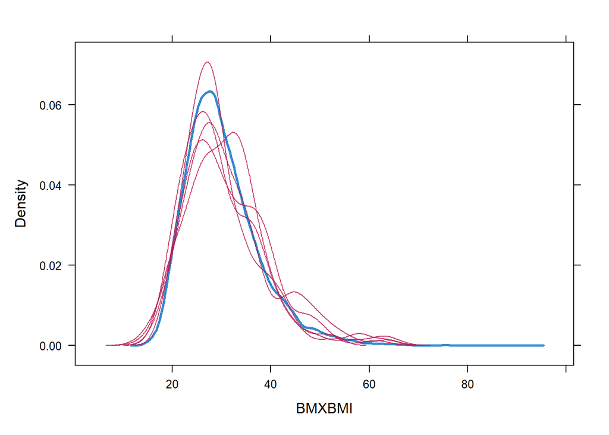

```r
densityplot(imp_model, ~BMXBMI)
```

The density plot for `BMXBMI` (Body Mass Index) compares the distribution of observed values (blue line) with the imputed values (red lines) across multiple imputed data sets. The imputed values closely follow the observed distribution, indicating that the Predictive Mean Matching (PMM) method successfully captured the overall data structure. There is a slight increase in variability among the imputed data sets, particularly in the higher BMI range, but this is expected given the natural spread of BMI values and the small number of extreme cases. Importantly, no major deviations or unrealistic patterns are observed, confirming that the imputation process preserved the integrity of the original data while effectively handling missing values.

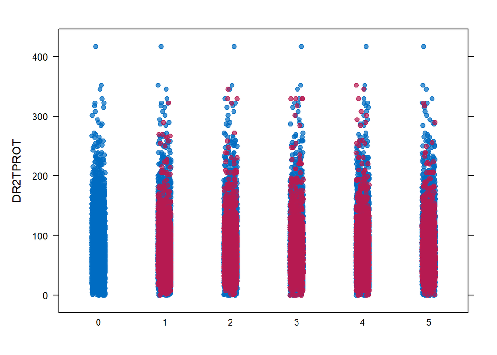

```r
stripplot(imp_model, DR2TPROT, pch = 20, cex = 1.2)
```

The strip plot for `DR2TPROT` visualizes the distribution of observed values and imputed values (red) across the five data sets. The imputed values are well integrated with the observed data following a similar spread and range indicating the the PPM captured the natural variation of the predictor. There do not appear to be any apparent clusters or extreme deviation among the imputed points suggesting no bias was introdcued to the dataset. The presence of higher protein consumption outliers in both observed and imputed data further supports the validity of the imputation approach. Overall, this visualization confirms that the missing values were imputed in a manner consistent with the original data distribution.

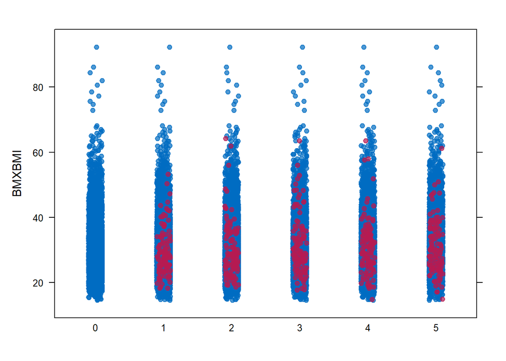

```r
stripplot(imp_model, BMXBMI, pch = 20, cex = 1.2)
```

The strip plot for `BMXBMI` shows a similar consistency as the `DR2TPROT` plot suggesting the chosen imputation method captured the structure of the data successfully. There are no apparent clusters or extreme deviations in the data suggesting no artificial bias.

The imputed dataset will be extracted.

```r
NH_data_imp <- complete(imp_model)
```

Check for the any missing variables in the dataset

```r
sum(is.na(NH_data_imp))
```

```
[1] 0
```

The imputated dataset will be saved

```r
saveRDS(NH_data_imp, here("data", "processed", "NH_data_imputed.Rds"))
```

# 5 Analysis 1: Difference in Protein Consumption Among Men and Women

## 5.1 The Question

The mean `DR2TPROT` (total protein consumption) of the male population will be compared to that of the female population. This analysis will use independent samples, as there is no direct relationship between the two groups in `RIAGENDR` that would influence each others `DR2TPROT` values. Additionally, the number of males and females in RIAGENDR is unequal, making the sample sizes unbalanced.

Our research question:

Is there a meaningful difference between total protein consumption between males and females?

## 5.2 Describing The Data

```r
favstats(DR2TPROT ~ RIAGENDR, data = NH_data_imp) %>% gt() %>% fmt_number(decimals = 2, columns = 2:8) %>%
  tab_options(table.width = pct(75)) %>%
  cols_align(align = "center")
```

| RIAGENDR | min | Q1 | median | Q3 | max | mean | sd | n | missing |
| --- | --- | --- | --- | --- | --- | --- | --- | --- | --- |
| Male | 0.00 | 56.22 | 80.27 | 108.41 | 352.25 | 86.58 | 43.91 | 3794 | 0 |
| Female | 0.00 | 42.65 | 60.98 | 82.56 | 417.30 | 66.22 | 34.56 | 4059 | 0 |

The numerical summary of total protein consumption (`DR2TPROT`) reveals notable differences between males and females. On average, males consume more protein (86.58g) than females (66.22g), with a higher median intake (80.27g vs. 60.98g) and a wider overall distribution. The interquartile range (IQR) for males (56.22g to 108.41g) is also higher compared to females (42.65g to 82.56g), suggesting greater variability in protein intake among men. The standard deviation further supports this, with males showing higher variability (43.91g) than females (34.56g). Both groups have a minimum reported intake of 0g. These results suggest a meaningful difference in protein consumption between genders, which will be further analyzed to determine statistical significance.

### 5.2.1 Graphical and Numerical Summaries

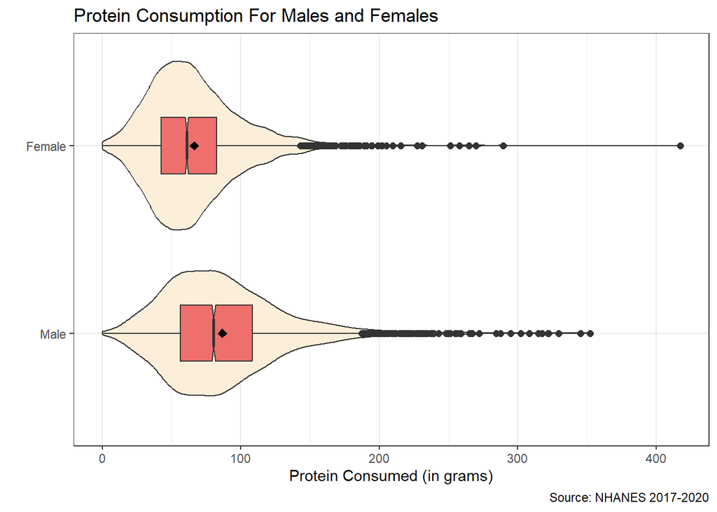

```r
NH_data_imp %>% ggplot(aes(x = RIAGENDR, y = DR2TPROT)) +
  geom_violin(fill = "#FCEFDA") +
  geom_boxplot(width = 0.3, notch = TRUE, fill = "#EF6F6C", outlier.size = 2) +
  coord_flip() +
  stat_summary(fun = "mean", geom = "point", shape = 23, size = 2, fill = "black") +
  labs(title = "Protein Consumption For Males and Females",
       x = "",
       y = "Protein Consumed (in grams)",
       caption = "Source: NHANES 2017-2020") -> Protein_Gender_Boxplot


ggsave(filename = here("figures", "Protein_Gender_Boxplot.png"), plot = Protein_Gender_Boxplot, width = 12, height = 10, dpi = 300)

Protein_Gender_Boxplot
```

The plot confirms that males generally consume more protein than females, as indicated by a higher median and mean protein intake. The spread of protein consumption is also greater for males, suggesting more variability in dietary habits. Both groups have outliers in the higher protein consumption range, which may reflect individuals with higher protein intake due to diet or lifestyle factors. This visualization reinforces the numerical summary findings and will be further examined through statistical testing.

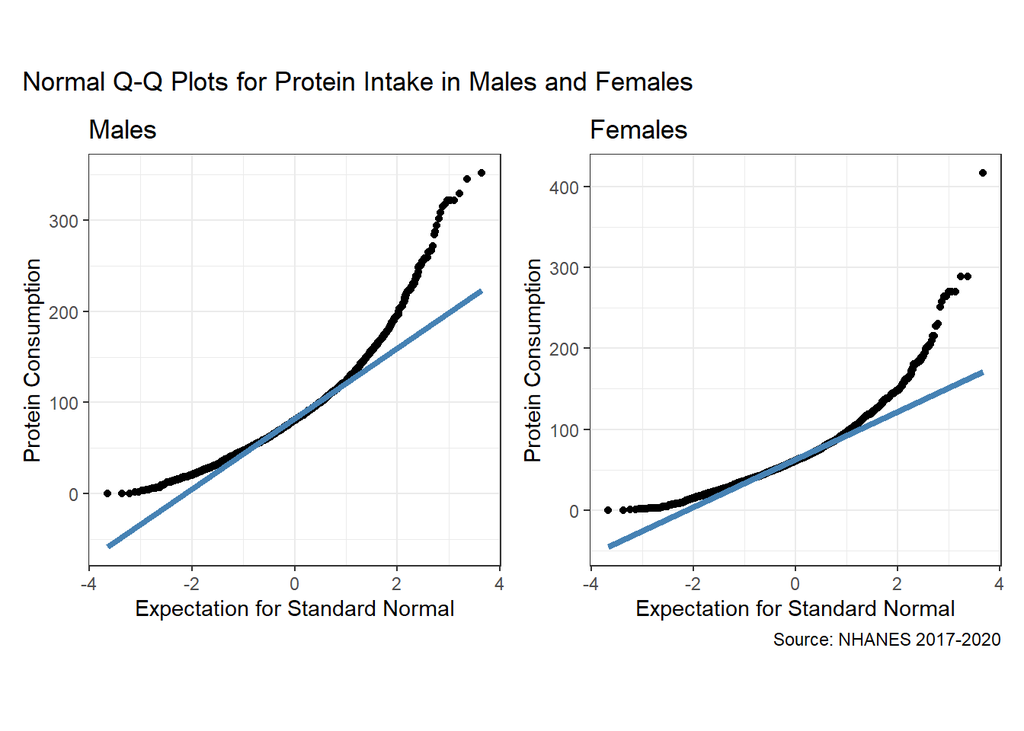

```r
# QQ plot for males
prot_m <- NH_data_imp %>%
  filter(RIAGENDR == "Male") %>%
  ggplot(aes(sample = DR2TPROT)) +
  geom_qq() +
  geom_qq_line(col = "steelblue", lwd = 1.5) +
  theme(aspect.ratio = 1) +
  labs(
    title = "Males",
    x = "Expectation for Standard Normal",
    y = "Protein Consumption")

# QQ plot for females
prot_f <- NH_data_imp %>%
  filter(RIAGENDR == "Female") %>%
  ggplot(aes(sample = DR2TPROT)) +
  geom_qq() +
  geom_qq_line(col = "steelblue", lwd = 1.5) +
  theme(aspect.ratio = 1) +
  labs(
    title = "Females",
    x = "Expectation for Standard Normal",
    y = "Protein Consumption",
    caption = "Source: NHANES 2017-2020")

Protein_QQ_Plots <- prot_m + prot_f +  plot_annotation(title = "Normal Q-Q Plots for Protein Intake in Males and Females")

# Save the combined plot as a high-resolution PNG
ggsave(filename = here("figures", "Protein_QQ_Plots.png"), plot = Protein_QQ_Plots, width = 12, height = 10, dpi = 300)

Protein_QQ_Plots
```

### 5.2.2 BoxCox for Transformation

A Box-Cox plot was used for `DR2TPROT` to address its non-normal distribution, as suggested by the Q-Q plots. Since Box-Cox transformations require strictly positive values, a small constant (0.01 grams) was added to all observations to accommodate subjects reporting 0 grams of protein intake.

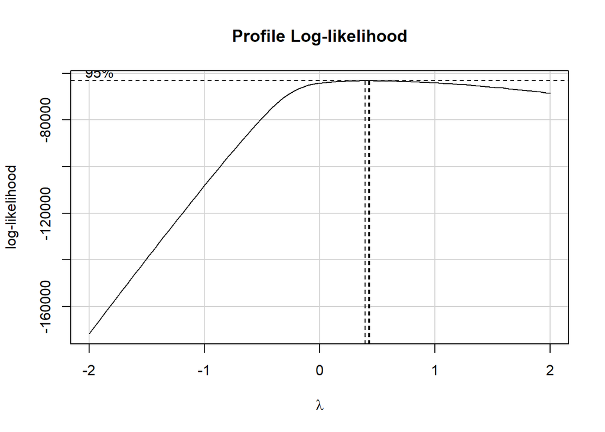

```r
boxCox(lm(DR2TPROT+0.01 ~ RIAGENDR, data = NH_data_imp))
```

```r
powerTransform(lm(DR2TPROT+ 0.01 ~ RIAGENDR, data = NH_data_imp)) # 0.41
```

```
Estimated transformation parameter
       Y1
0.4143391
```

The Box-Cox plot suggests a transformation parameter close to 0.5, and the estimated transformation value from `powerTransform()` is 0.41, further confirming this recommendation. A power of 0.5 corresponds to a square root transformation, which will be applied to assess whether it improves normality. This transformation aims to reduce skewness and stabilize variance, making the data more suitable for parametric analyses.

### 5.2.3 Transformation of the Data

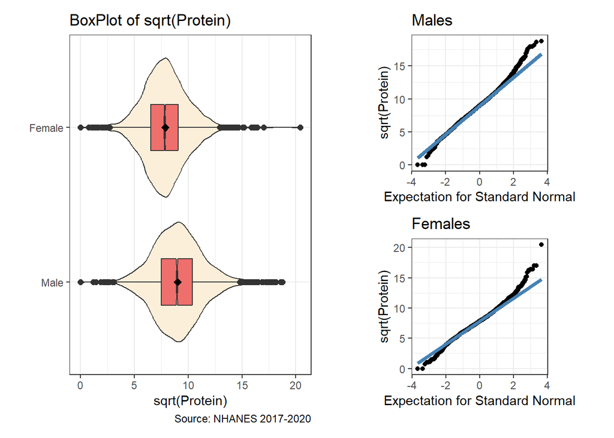

```r
pp <- NH_data_imp %>%
  ggplot(aes(x = RIAGENDR, y = sqrt(DR2TPROT))) +
  geom_violin(fill = "#FCEFDA") +
  geom_boxplot(width = 0.3, notch = TRUE, fill = "#EF6F6C", outlier.size = 2) +
  coord_flip() +
  stat_summary(fun = "mean", geom = "point", shape = 23, size = 2, fill = "black") +
  labs(
    title = "BoxPlot of sqrt(Protein)",
    x = "",
    y = "sqrt(Protein)",
    caption = "Source: NHANES 2017-2020"
  )


prot_m2 <- NH_data_imp %>%
  filter(RIAGENDR == "Male") %>%
  ggplot(aes(sample = sqrt(DR2TPROT))) +
  geom_qq() +
  geom_qq_line(col = "steelblue", lwd = 1.5) +
  theme(aspect.ratio = 1) +
  labs(
    title = "Males",
    x = "Expectation for Standard Normal",
    y = "sqrt(Protein)"
  )


prot_f2 <- NH_data_imp %>%
  filter(RIAGENDR == "Female") %>%
  ggplot(aes(sample = sqrt(DR2TPROT))) +
  geom_qq() +
  geom_qq_line(col = "steelblue", lwd = 1.5) +
  theme(aspect.ratio = 1) +
  labs(
    title = "Females",
    x = "Expectation for Standard Normal",
    y = "sqrt(Protein)"
  )


sqrt_Protein_Plots <- pp + (prot_m2 / prot_f2)

ggsave(filename = here("figures", "sqrt_Protein_Plots.png"), plot = sqrt_Protein_Plots, width = 12, height = 10, dpi = 300)

sqrt_Protein_Plots
```

The BoxPlot and Q-Q plots visualize the effects of applying a square root transformation to total protein consumption (`DR2TPROT`). The transformation was performed based on the Box-Cox analysis, which suggested a transformation parameter close to 0.5. The violin-boxplot shows that while the transformed data remains slightly skewed, the distribution appears more symmetric compared to the original scale. The Q-Q plots for males and females indicate improved normality, with data points aligning more closely with the diagonal reference line. However, slight deviations persist in the lower and upper tails, suggesting that while the transformation reduces skewness, perfect normality is not achieved. This transformation will enhance the validity of parametric statistical tests by stabilizing variance and making the distribution more suitable for further analysis.

### 5.2.4 Variance and Normality Checks

To determine whether the assumption of equal variances holds between males and females, we perform Levene’s test on the square root-transformed `DR2TPROT` values.

```r
leveneTest(sqrt(DR2TPROT) ~ RIAGENDR, data = NH_data_imp)
```

```
Levene's Test for Homogeneity of Variance (center = median)
        Df F value    Pr(>F)
group    1  38.764 5.029e-10 ***
      7851
---
Signif. codes:  0 '***' 0.001 '**' 0.01 '*' 0.05 '.' 0.1 ' ' 1
```

To assess whether protein consumption for each group follows a normal distribution after transformation, we apply the Shapiro-Wilk test to the square root-transformed values.

```r
# Ensure the variable is numeric
shapiro.test(NH_data_imp %>% filter(RIAGENDR == "Male") %>% pull(DR2TPROT) %>% sqrt())
```

```
    Shapiro-Wilk normality test

data:  NH_data_imp %>% filter(RIAGENDR == "Male") %>% pull(DR2TPROT) %>% sqrt()
W = 0.99197, p-value = 8.66e-14
```

```r
shapiro.test(NH_data_imp %>% filter(RIAGENDR == "Female") %>% pull(DR2TPROT) %>% sqrt())
```

```
    Shapiro-Wilk normality test

data:  NH_data_imp %>% filter(RIAGENDR == "Female") %>% pull(DR2TPROT) %>% sqrt()
W = 0.98968, p-value < 2.2e-16
```

The results indicate that Levene’s test is highly significant (p < 0.001), meaning the assumption of equal variances is violated, requiring the use of Welch’s t-test instead of a pooled-variance t-test. Additionally, the Shapiro-Wilk test results for both males (p = 8.66e-14) and females (p < 2.2e-16) suggest strong deviations from normality, even after transformation. Given these findings, a non-parametric alternative (such as bootstrapping) remains the most robust approach for comparing protein consumption between genders.

## 5.3 Main Analysis

```r
set.seed(444)

male_pro <- NH_data_imp %>% filter(RIAGENDR == "Male") %>% pull(DR2TPROT)
female_pro <- NH_data_imp %>% filter(RIAGENDR == "Female") %>% pull(DR2TPROT)

boot.t.test(x = male_pro, y = female_pro, alternative = 'two.sided', conf.level = 0.95, paried = FALSE, var.equal = FALSE, R = 10000)
```

```
    Bootstrap Welch Two Sample t-test

data:  male_pro and female_pro
number of bootstrap samples:  10000
bootstrap p-value < 1e-04
bootstrap difference of means (SE) = 20.33699 (0.8954913)
95 percent bootstrap percentile confidence interval:
 18.58277 22.08416

Results without bootstrap:
t = 22.72, df = 7200.9, p-value < 2.2e-16
alternative hypothesis: true difference in means is not equal to 0
95 percent confidence interval:
 18.59644 22.10851
sample estimates:
mean of x mean of y
 86.57570  66.22322
```

The bootstrapped Welch two-sample t-test was conducted to compare the mean protein consumption (`DR2TPROT`) between males and females. Using 10000 bootstrap resamples, the bootstrap p-value was < 0.0001, indicating a statistically significant difference in protein intake between genders. The bootstrap estimate of the mean difference was 20.34 grams (SE = 0.90), with a 95% confidence interval (18.58g, 22.08g), suggesting that males consistently consume more protein than females.

## 5.4 Conclusions

The results of the bootstrapped two-sample t-test provide strong evidence that males consume significantly more protein than females. With 10,000 bootstrap resamples, the estimated mean difference in protein intake was 20.34 grams (SE = 0.90), and the 95% confidence interval (18.58g, 22.08g) confirms that this difference is unlikely due to random variation. The bootstrap p-value (< 0.0001) further supports the statistical significance of this finding. Since bootstrapping does not rely on normality or equal variance assumptions, these results are robust and reliable, reinforcing the conclusion that males have a consistently higher protein intake compared to females.

One limitation of our analysis is that `DR2TPROT` only reflects total protein consumption for a single day, which may not accurately represent an individual’s long-term dietary habits. Daily protein intake can vary due to lifestyle factors or temporary dietary choices, meaning our estimates may not fully capture habitual protein consumption patterns between gender. Additionally, we did not account for dietary reporting bias, where individuals may under report or over report their intake. Future research should consider analyzing multiple days of dietary intake or incorporating habitual dietary assessment methods to obtain a more accurate picture of protein consumption trends.

# 6 Analysis 2: Comparing 5 Population Means with Independent Samples

## 6.1 The Question

This analysis will use the variables `DBQ750` and `BMXBMI` to compare the mean BMI (`BMXBMI`) across different groups based on how frequently individuals read nutrition labels before purchasing food items. The five groups represent individuals who always, most of the time, sometimes, rarely, or never read nutrition labels. These groups are independent, meaning that an individual’s frequency of reading nutrition labels has no effect on the BMI of other subjects. To compare the groups, an analysis of variance and 95% confidence intervals will be used.

Research Question: Is there an association between an individual’s BMI and the frequency with which they read nutrition labels on food products before purchasing them?

## 6.2 Describing The Data

### 6.2.1 Numerical Summary

To begin, we examine the numerical summary of BMI (`BMXBMI`) across the five groups categorized by nutrition label reading frequency (`DBQ750`).

```r
favstats(BMXBMI ~ DBQ750, data = NH_data_imp) %>% gt() %>% fmt_number(decimals = 2, columns = 2:8) %>%
  tab_options(table.width = pct(75)) %>%
  cols_align(align = "center")
```

| DBQ750 | min | Q1 | median | Q3 | max | mean | sd | n | missing |
| --- | --- | --- | --- | --- | --- | --- | --- | --- | --- |
| Always | 15.40 | 25.00 | 28.55 | 33.40 | 74.80 | 29.71 | 7.11 | 1218 | 0 |
| Most of the time | 14.60 | 25.20 | 28.90 | 34.00 | 80.60 | 30.39 | 7.70 | 1910 | 0 |
| Sometimes | 14.90 | 25.20 | 29.40 | 34.90 | 92.30 | 30.76 | 8.09 | 2771 | 0 |
| Rarely | 15.40 | 24.80 | 28.70 | 34.10 | 77.30 | 30.17 | 7.65 | 1037 | 0 |
| Never | 15.10 | 24.40 | 27.90 | 32.60 | 66.20 | 29.00 | 6.80 | 917 | 0 |

The mean BMI across groups is relatively similar, with the “Sometimes” group having the highest mean BMI (30.76) and the “Never” group having the lowest (29.00). This pattern is also reflected in the median values, where individuals who sometimes read nutrition labels have the highest median BMI (29.40), while those who never read them have the lowest (27.90). In all groups, the mean BMI is higher than the median, indicating that the distributions are right-skewed, with a subset of individuals having higher BMI values. The standard deviations range from 6.80 to 8.09, suggesting some variability in BMI within each group. Furthermore, the number of subjects in each category varies, with the “Sometimes” group having the largest sample size (n = 2771) and the “Never” group having the smallest (n = 917). The unequal sample sizes further confirm that subjects are independent across groups, ensuring validity in comparing their BMI distributions.